# lab05-jose-lucar.Rmd

Jose Lucar

9/28/2018

```r
library(dplyr)
```

```r
library(ggplot2)
library(readr)
```

- *This option to download the data only worked when the data is in your working directory. of course, you can acces the data direcctory from here in order to download a new data* for example you can use the following when your data is inside the **Data* directory:
  - *dat <- read_csv(‘../Data/’nba2018-players.csv’)*

```r
dat <- read_csv('../Data/nba2018-players.csv')
```

- **slice() allows you to select rows by position**

```r
three_rows<- slice(dat, 1:3)
three_rows
```

```
## # A tibble: 3 x 15
##          player  team position height weight   age experience
##           <chr> <chr>    <chr>  <int>  <int> <int>      <int>
## 1    Al Horford   BOS        C     82    245    30          9
## 2  Amir Johnson   BOS       PF     81    240    29         11
## 3 Avery Bradley   BOS       SG     74    180    26          6
## # ... with 8 more variables: college <chr>, salary <dbl>, games <int>,
## #   minutes <int>, points <int>, points3 <int>, points2 <int>,
## #   points1 <int>
```

- **filter() allows you to select rows by condition***

```r
gt_85<- filter(dat, height > 85)
gt_85
```

```
## # A tibble: 5 x 15
##               player  team position height weight   age experience
##                <chr> <chr>    <chr>  <int>  <int> <int>      <int>
## 1        Edy Tavares   CLE        C     87    260    24          1
## 2   Boban Marjanovic   DET        C     87    290    28          1
## 3 Kristaps Porzingis   NYK       PF     87    240    21          1
## 4        Roy Hibbert   DEN        C     86    270    30          8
## 5      Alexis Ajinca   NOP        C     86    248    28          6
## # ... with 8 more variables: college <chr>, salary <dbl>, games <int>,
## #   minutes <int>, points <int>, points3 <int>, points2 <int>,
## #   points1 <int>
```

- **select() allows you to select columns by name***

```r
player_height<- select(dat, player,height)
player_height
```

```
## # A tibble: 477 x 2
##               player height
##                <chr>  <int>
##  1        Al Horford     82
##  2      Amir Johnson     81
##  3     Avery Bradley     74
##  4 Demetrius Jackson     73
##  5      Gerald Green     79
##  6     Isaiah Thomas     69
##  7       Jae Crowder     78
##  8       James Young     78
##  9      Jaylen Brown     79
## 10     Jonas Jerebko     82
## # ... with 467 more rows
```

### Your Turn:

- **use ‘slice()’ to subset the data by selecting the first 5 rows.**

```r
slice(dat, 1:5)
```

```
## # A tibble: 5 x 15
##              player  team position height weight   age experience
##               <chr> <chr>    <chr>  <int>  <int> <int>      <int>
## 1        Al Horford   BOS        C     82    245    30          9
## 2      Amir Johnson   BOS       PF     81    240    29         11
## 3     Avery Bradley   BOS       SG     74    180    26          6
## 4 Demetrius Jackson   BOS       PG     73    201    22          0
## 5      Gerald Green   BOS       SF     79    205    31          9
## # ... with 8 more variables: college <chr>, salary <dbl>, games <int>,
## #   minutes <int>, points <int>, points3 <int>, points2 <int>,
## #   points1 <int>
```

- **use slice() to subset the data by selecting rows 10, 15, 20, …, 50.**

```r
sli_rows<- c(seq( from = 10, to = 50, by = 5))
slice(dat, sli_rows)
```

```
## # A tibble: 9 x 15
##             player  team position height weight   age experience
##              <chr> <chr>    <chr>  <int>  <int> <int>      <int>
## 1    Jonas Jerebko   BOS       PF     82    231    29          6
## 2     Tyler Zeller   BOS        C     84    253    27          4
## 3 Derrick Williams   CLE       PF     80    240    25          5
## 4     Jordan McRae   CLE       SG     78    185    25          1
## 5    Larry Sanders   CLE        C     83    235    28          5
## 6      Cory Joseph   TOR       PG     75    193    25          5
## 7     Jakob Poeltl   TOR        C     84    248    21          0
## 8      P.J. Tucker   TOR       SF     78    245    31          5
## 9     Bradley Beal   WAS       SG     77    207    23          4
## # ... with 8 more variables: college <chr>, salary <dbl>, games <int>,
## #   minutes <int>, points <int>, points3 <int>, points2 <int>,
## #   points1 <int>
```

- **use slice() to subset the data by selecting the last 5 rows.**

```r
slice(tail(dat,n=5))
```

```
## # A tibble: 5 x 15
##            player  team position height weight   age experience
##             <chr> <chr>    <chr>  <int>  <int> <int>      <int>
## 1 Marquese Chriss   PHO       PF     82    233    19          0
## 2    Ronnie Price   PHO       PG     74    190    33         11
## 3     T.J. Warren   PHO       SF     80    230    23          2
## 4      Tyler Ulis   PHO       PG     70    150    21          0
## 5  Tyson Chandler   PHO        C     85    240    34         15
## # ... with 8 more variables: college <chr>, salary <dbl>, games <int>,
## #   minutes <int>, points <int>, points3 <int>, points2 <int>,
## #   points1 <int>
```

- **use filter() to subset those players with height less than 70 inches tall.**

```r
filter(dat, height<70)
```

```
## # A tibble: 2 x 15
##          player  team position height weight   age experience
##           <chr> <chr>    <chr>  <int>  <int> <int>      <int>
## 1 Isaiah Thomas   BOS       PG     69    185    27          5
## 2    Kay Felder   CLE       PG     69    176    21          0
## # ... with 8 more variables: college <chr>, salary <dbl>, games <int>,
## #   minutes <int>, points <int>, points3 <int>, points2 <int>,
## #   points1 <int>
```

- **use filter() to subset rows of Golden State Warriors (‘GSW’)**

```r
filter(dat, team == 'GSW')
```

```
## # A tibble: 16 x 15
##                  player  team position height weight   age experience
##                   <chr> <chr>    <chr>  <int>  <int> <int>      <int>
##  1     Anderson Varejao   GSW        C     82    273    34         12
##  2       Andre Iguodala   GSW       SF     78    215    33         12
##  3         Damian Jones   GSW        C     84    245    21          0
##  4           David West   GSW        C     81    250    36         13
##  5       Draymond Green   GSW       PF     79    230    26          4
##  6            Ian Clark   GSW       SG     75    175    25          3
##  7 James Michael McAdoo   GSW       PF     81    230    24          2
##  8         JaVale McGee   GSW        C     84    270    29          8
##  9         Kevin Durant   GSW       PF     81    240    28          9
## 10         Kevon Looney   GSW        C     81    220    20          1
## 11        Klay Thompson   GSW       SG     79    215    26          5
## 12          Matt Barnes   GSW       SF     79    226    36         13
## 13        Patrick McCaw   GSW       SG     79    185    21          0
## 14     Shaun Livingston   GSW       PG     79    192    31         11
## 15        Stephen Curry   GSW       PG     75    190    28          7
## 16        Zaza Pachulia   GSW        C     83    270    32         13
## # ... with 8 more variables: college <chr>, salary <dbl>, games <int>,
## #   minutes <int>, points <int>, points3 <int>, points2 <int>,
## #   points1 <int>
```

- **use filter() to subset rows of GSW centers (‘C’)**

```r
filter(dat, team == 'GSW' & position == 'C')
```

```
## # A tibble: 6 x 15
##             player  team position height weight   age experience
##              <chr> <chr>    <chr>  <int>  <int> <int>      <int>
## 1 Anderson Varejao   GSW        C     82    273    34         12
## 2     Damian Jones   GSW        C     84    245    21          0
## 3       David West   GSW        C     81    250    36         13
## 4     JaVale McGee   GSW        C     84    270    29          8
## 5     Kevon Looney   GSW        C     81    220    20          1
## 6    Zaza Pachulia   GSW        C     83    270    32         13
## # ... with 8 more variables: college <chr>, salary <dbl>, games <int>,
## #   minutes <int>, points <int>, points3 <int>, points2 <int>,
## #   points1 <int>
```

- **use filter() and then select(), to subset rows of lakers (‘LAL’), and then display their names.**

```r
select(filter(dat, team == "LAL"), player)
```

```
## # A tibble: 14 x 1
##               player
##                <chr>
##  1    Brandon Ingram
##  2      Corey Brewer
##  3  D'Angelo Russell
##  4       David Nwaba
##  5       Ivica Zubac
##  6   Jordan Clarkson
##  7     Julius Randle
##  8         Luol Deng
##  9 Metta World Peace
## 10        Nick Young
## 11       Tarik Black
## 12   Thomas Robinson
## 13    Timofey Mozgov
## 14       Tyler Ennis
```

```r
select(filter(dat, team == "GSW"), player, salary)
```

```
## # A tibble: 16 x 2
##                  player   salary
##                   <chr>    <dbl>
##  1     Anderson Varejao  1551659
##  2       Andre Iguodala 11131368
##  3         Damian Jones  1171560
##  4           David West  1551659
##  5       Draymond Green 15330435
##  6            Ian Clark  1015696
##  7 James Michael McAdoo   980431
##  8         JaVale McGee  1403611
##  9         Kevin Durant 26540100
## 10         Kevon Looney  1182840
## 11        Klay Thompson 16663575
## 12          Matt Barnes   383351
## 13        Patrick McCaw   543471
## 14     Shaun Livingston  5782450
## 15        Stephen Curry 12112359
## 16        Zaza Pachulia  2898000
```

- **find how to select the name, age, and team, of players with more than 10 years of experience, making 10 million dollars or less.**

```r
select(filter(dat, salary <= 10000000 & experience > 10), player, age, team)
```

```
## # A tibble: 36 x 3
##               player   age  team
##                <chr> <int> <chr>
##  1      Andrew Bogut    32   CLE
##  2     Dahntay Jones    36   CLE
##  3    Deron Williams    32   CLE
##  4       James Jones    36   CLE
##  5       Kyle Korver    35   CLE
##  6 Richard Jefferson    36   CLE
##  7     Jose Calderon    35   ATL
##  8    Kris Humphries    31   ATL
##  9     Mike Dunleavy    36   ATL
## 10       Jason Terry    39   MIL
## # ... with 26 more rows
```

- **find how to select the name, team, height, and weight, of rookie players, 20 years old, displaying only the first five occurrences (i.e. rows)**

```r
slice(select(filter(dat, age == "20") , player, team, height, weight)   ,1:5)
```

```
## # A tibble: 5 x 4
##            player  team height weight
##             <chr> <chr>  <int>  <int>
## 1    Jaylen Brown   BOS     79    225
## 2   Rashad Vaughn   MIL     78    202
## 3    Myles Turner   IND     83    243
## 4 Justise Winslow   MIA     79    225
## 5  Henry Ellenson   DET     83    245
```

- **using the data frame gsw, add a new variable product with the product of height and weight.**

```r
gsw <- filter(dat, team == 'GSW')
gsw <- select(gsw, player, height, weight)
gsw <- slice(gsw, c(4, 8, 10, 14, 15))
mutate(gsw, height*weight)
```

```
## # A tibble: 5 x 4
##             player height weight `height * weight`
##              <chr>  <int>  <int>             <int>
## 1       David West     81    250             20250
## 2     JaVale McGee     84    270             22680
## 3     Kevon Looney     81    220             17820
## 4 Shaun Livingston     79    192             15168
## 5    Stephen Curry     75    190             14250
```

- **create a new data frame gsw3, by adding columns log_height and log_weight with the log transformations of height and weight.**

```r
gsw3<-mutate(gsw, log_height=log(height), log_weight=log(weight))
```

- **use the original data frame to filter() and arrange() those players with height less than 71 inches tall, in increasing order.**

```r
arrange(filter(dat, height<71), height)
```

```
## # A tibble: 4 x 15
##           player  team position height weight   age experience
##            <chr> <chr>    <chr>  <int>  <int> <int>      <int>
## 1  Isaiah Thomas   BOS       PG     69    185    27          5
## 2     Kay Felder   CLE       PG     69    176    21          0
## 3 Pierre Jackson   DAL       PG     70    180    25          0
## 4     Tyler Ulis   PHO       PG     70    150    21          0
## # ... with 8 more variables: college <chr>, salary <dbl>, games <int>,
## #   minutes <int>, points <int>, points3 <int>, points2 <int>,
## #   points1 <int>
```

- **display the name, team, and salary, of the top-5 highest paid players**

```r
slice(select(arrange(dat, desc(salary)),  player, team , salary), 1:5)
```

```
## # A tibble: 5 x 3
##          player  team   salary
##           <chr> <chr>    <dbl>
## 1  LeBron James   CLE 30963450
## 2    Al Horford   BOS 26540100
## 3 DeMar DeRozan   TOR 26540100
## 4  Kevin Durant   GSW 26540100
## 5  James Harden   HOU 26540100
```

```r
dat
```

```
## # A tibble: 477 x 15
##               player  team position height weight   age experience
##                <chr> <chr>    <chr>  <int>  <int> <int>      <int>
##  1        Al Horford   BOS        C     82    245    30          9
##  2      Amir Johnson   BOS       PF     81    240    29         11
##  3     Avery Bradley   BOS       SG     74    180    26          6
##  4 Demetrius Jackson   BOS       PG     73    201    22          0
##  5      Gerald Green   BOS       SF     79    205    31          9
##  6     Isaiah Thomas   BOS       PG     69    185    27          5
##  7       Jae Crowder   BOS       SF     78    235    26          4
##  8       James Young   BOS       SG     78    215    21          2
##  9      Jaylen Brown   BOS       SF     79    225    20          0
## 10     Jonas Jerebko   BOS       PF     82    231    29          6
## # ... with 467 more rows, and 8 more variables: college <chr>,
## #   salary <dbl>, games <int>, minutes <int>, points <int>, points3 <int>,
## #   points2 <int>, points1 <int>
```

- **display the name, team, and points3, of the top 10 three-point players**

```r
slice(select(arrange(dat, desc(points3)), player, team, points3), 1:10)
```

```
## # A tibble: 10 x 3
##            player  team points3
##             <chr> <chr>   <int>
##  1  Stephen Curry   GSW     324
##  2  Klay Thompson   GSW     268
##  3   James Harden   HOU     262
##  4    Eric Gordon   HOU     246
##  5  Isaiah Thomas   BOS     245
##  6   Kemba Walker   CHO     240
##  7   Bradley Beal   WAS     223
##  8 Damian Lillard   POR     214
##  9  Ryan Anderson   HOU     204
## 10    J.J. Redick   LAC     201
```

```r
dat
```

```
## # A tibble: 477 x 15
##               player  team position height weight   age experience
##                <chr> <chr>    <chr>  <int>  <int> <int>      <int>
##  1        Al Horford   BOS        C     82    245    30          9
##  2      Amir Johnson   BOS       PF     81    240    29         11
##  3     Avery Bradley   BOS       SG     74    180    26          6
##  4 Demetrius Jackson   BOS       PG     73    201    22          0
##  5      Gerald Green   BOS       SF     79    205    31          9
##  6     Isaiah Thomas   BOS       PG     69    185    27          5
##  7       Jae Crowder   BOS       SF     78    235    26          4
##  8       James Young   BOS       SG     78    215    21          2
##  9      Jaylen Brown   BOS       SF     79    225    20          0
## 10     Jonas Jerebko   BOS       PF     82    231    29          6
## # ... with 467 more rows, and 8 more variables: college <chr>,
## #   salary <dbl>, games <int>, minutes <int>, points <int>, points3 <int>,
## #   points2 <int>, points1 <int>
```

- **create a data frame gsw_mpg of GSW players, that contains variables for player name, experience, and min_per_game (minutes per game), sorted by min_per_game (in descending order)**

```r
gsw_mpg<- select(arrange(filter(mutate(dat, min_per_game=minutes/games ), team=="GSW"), desc(min_per_game)), player, experience, min_per_game)
```

- **use summarise() to get the largest height value.**

```r
summarise(dat, max(height))
```

```
## # A tibble: 1 x 1
##   `max(height)`
##           <dbl>
## 1            87
```

- **use summarise() to get the standard deviation of points3**

```r
summarise(dat, std_points3 = sd(points3))
```

```
## # A tibble: 1 x 1
##   std_points3
##         <dbl>
## 1    55.11807
```

- **use summarise() and group_by() to display the median of three-points, by team.**

```r
summarise(group_by(dat, team), three_points = median(points3))
```

```
## # A tibble: 30 x 2
##     team three_points
##    <chr>        <dbl>
##  1   ATL         32.0
##  2   BOS         46.0
##  3   BRK         36.0
##  4   CHI         28.5
##  5   CHO         13.0
##  6   CLE         26.5
##  7   DAL         18.0
##  8   DEN         46.0
##  9   DET         28.0
## 10   GSW         10.5
## # ... with 20 more rows
```

```r
arrange(slice(tail(summarise(group_by(dat, team), aver_3pointers = mean(points3)), n=5)), aver_3pointers)
```

```
## # A tibble: 5 x 2
##    team aver_3pointers
##   <chr>          <dbl>
## 1   SAC       35.12500
## 2   TOR       41.73333
## 3   SAS       47.06250
## 4   WAS       47.86667
## 5   UTA       52.73333
```

- **obtain the mean and standard deviation of age, for Power Forwards, with 5 and 10 years (including) years of experience.**

```r
summarise(filter(dat, position == "PF" & experience >= 5 & experience<= 10) , mean_age= mean(age) , sd_age= sd(age))
```

```
## # A tibble: 1 x 2
##   mean_age   sd_age
##      <dbl>    <dbl>
## 1 28.43243 2.267408
```

### First contact with ggplot()

- **Use the data frame gsw to make a scatterplot of height and weight.**

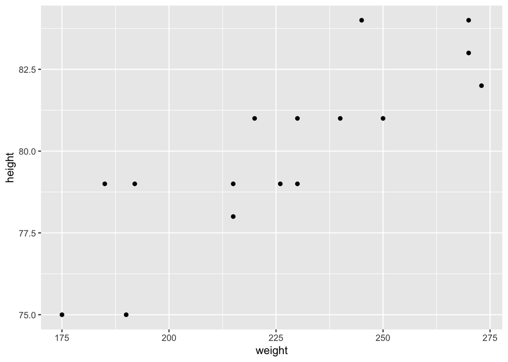

```r
GSW<- filter(dat, team== "GSW")
ggplot(data= GSW) + geom_point(aes(x=weight, y=height))
```

- **Find out how to make another scatterplot of height and weight, using geom_text() to display the names of the players.**

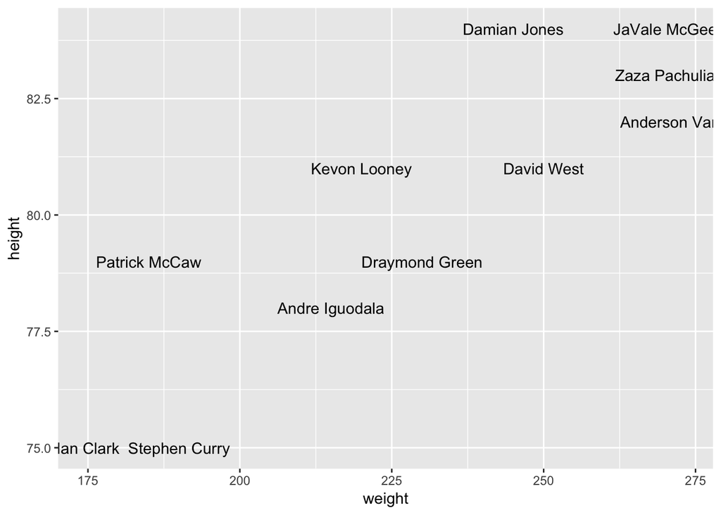

```r
ggplot(GSW, aes(weight, height, label= player)) +geom_text( check_overlap = TRUE)
```

- **Get a scatter plot of height and weight, for ALL the warriors, displaying their names with geom_label().**

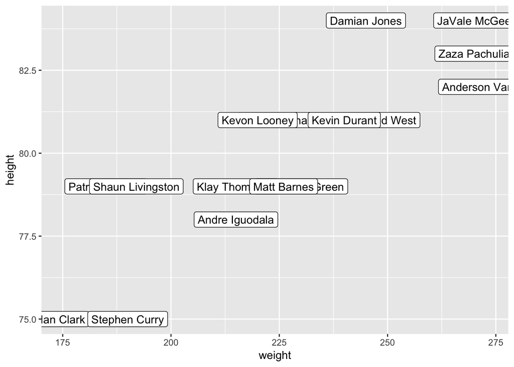

```r
ggplot(GSW, aes(weight, height, label= player)) +geom_label( check_overlap = TRUE)
```

- **Get a density plot of salary (for all NBA players).**

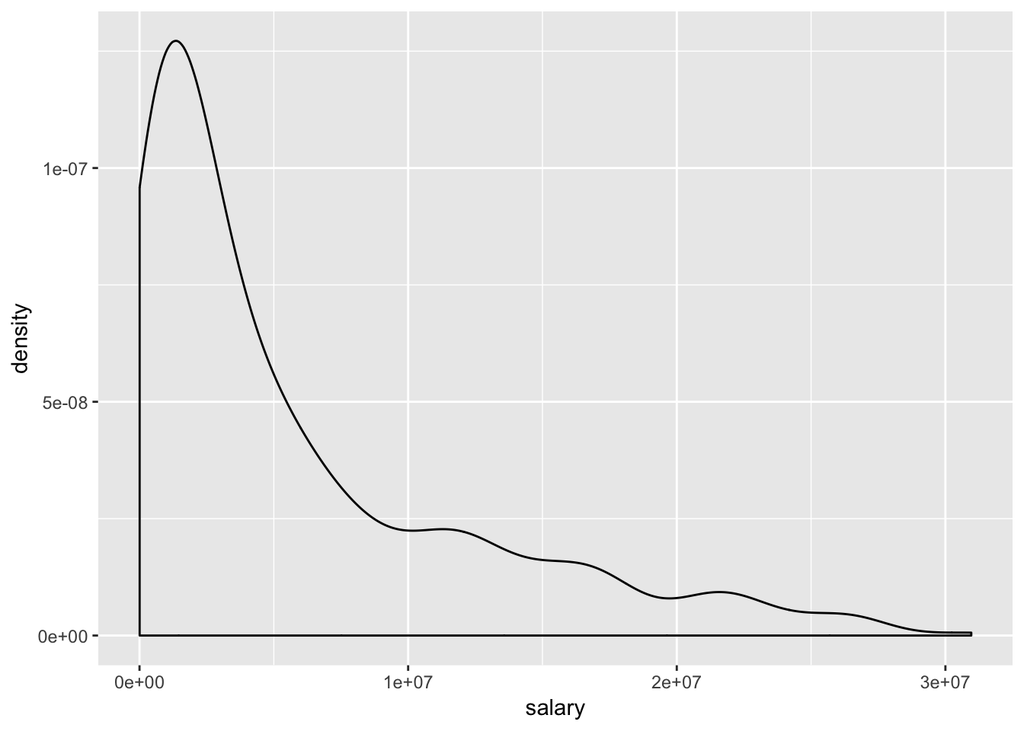

```r
ggplot(dat, aes(x=salary))+geom_density()
```

- **Get a histogram of points2 with binwidth of 50 (for all NBA players).**

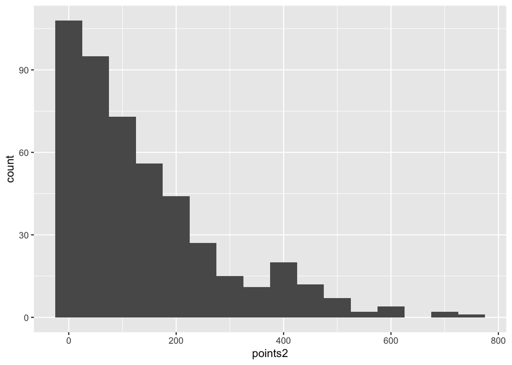

```r
ggplot(dat, aes(x=points2))+ geom_histogram(binwidth = 50)
```

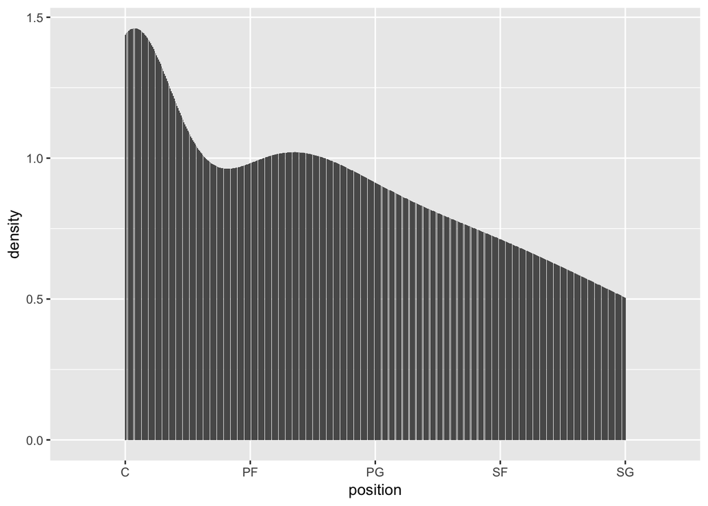

```r
ggplot(dat, aes(x=position)) + geom_bar(stat= 'density')
```

- **Make a scatterplot of experience and salary of all Centers, and use geom_smooth() to add a regression line.**

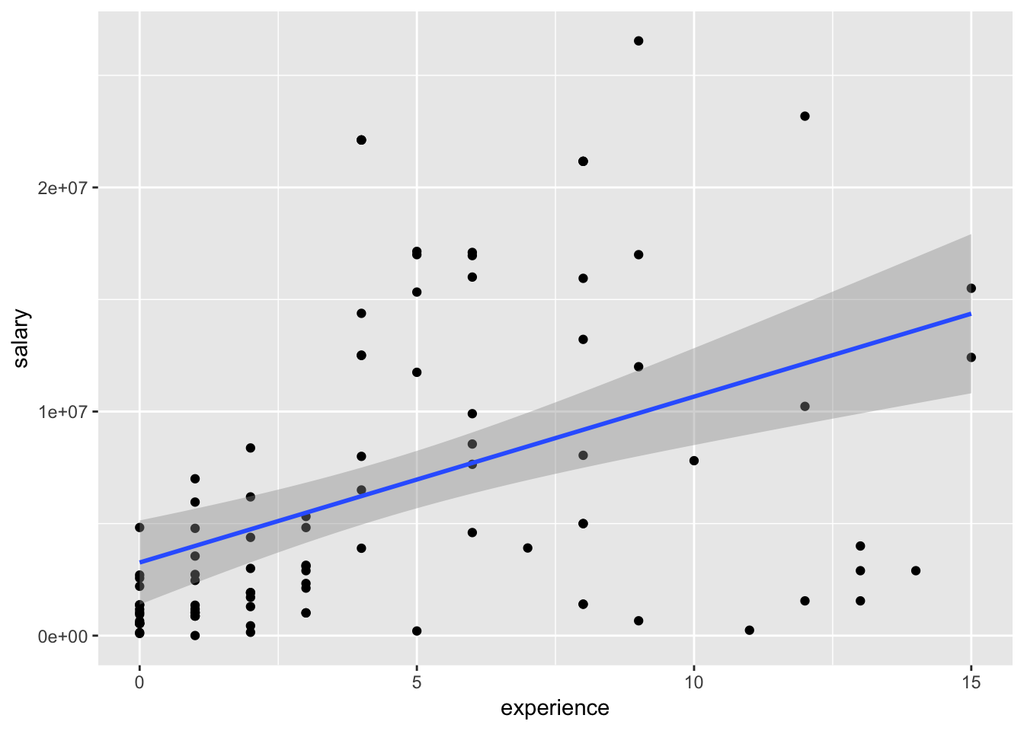

```r
ggplot(filter(dat, position == 'C'),aes(x = experience, y = salary)) + geom_point() +geom_smooth(method = lm)
```

- **Repeat the same scatterplot of experience and salary of all Centers, but now use geom_smooth() to add a loess line (i.e. smooth line).**

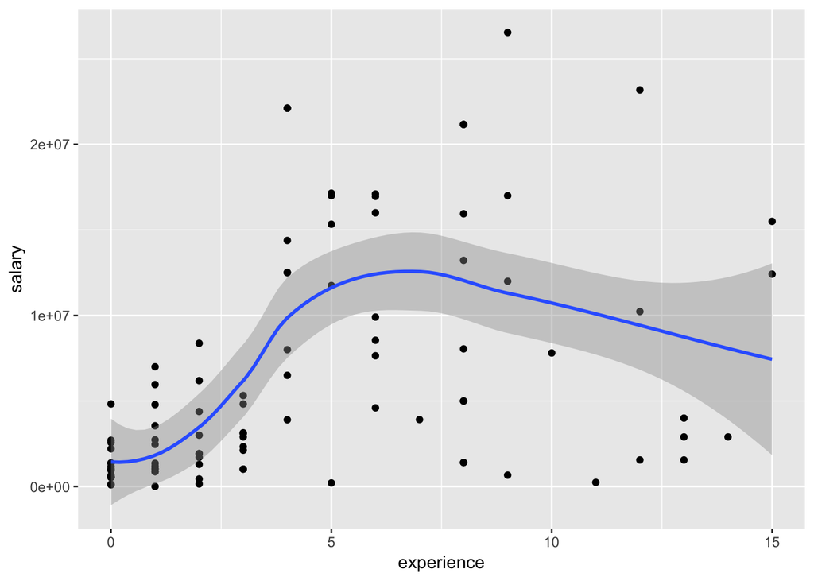

```r
ggplot(filter(dat, position == 'C'),aes(x = experience, y = salary)) + geom_point() +geom_smooth(method = loess)
```

- ** Make scatterplots of `experience` and `salary` faceting by `position`**

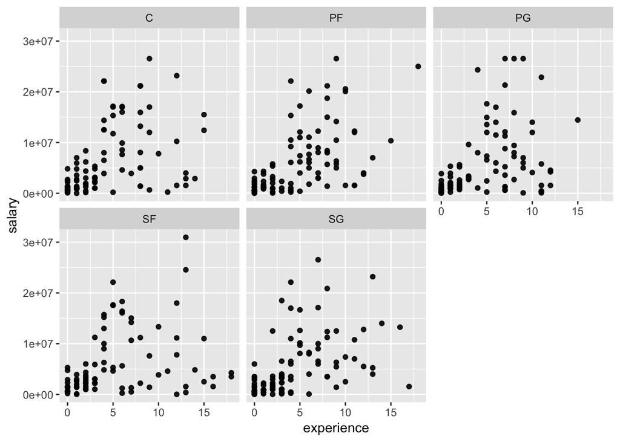

```r
ggplot(dat, aes(x = experience, y = salary)) +geom_point(alpha = 0.9) +facet_wrap(~ position)
```

- **Make scatterplots of `experience` and `salary` faceting by `team`**

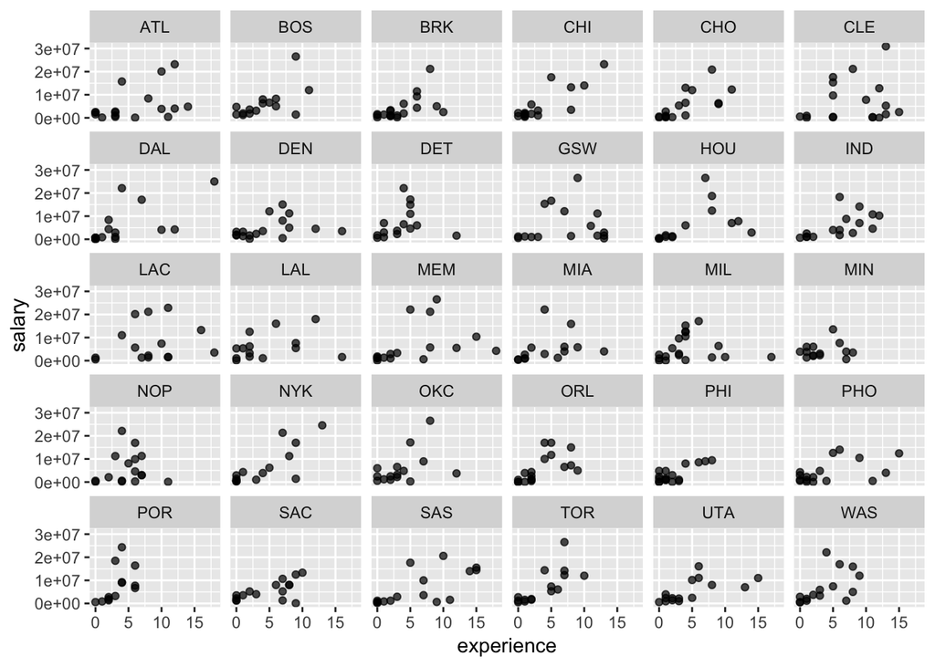

```r
ggplot(dat, aes(x = experience, y = salary)) +geom_point(alpha = 0.7) +facet_wrap(~ team)
```

- **Make density plots of `age` faceting by `team`**

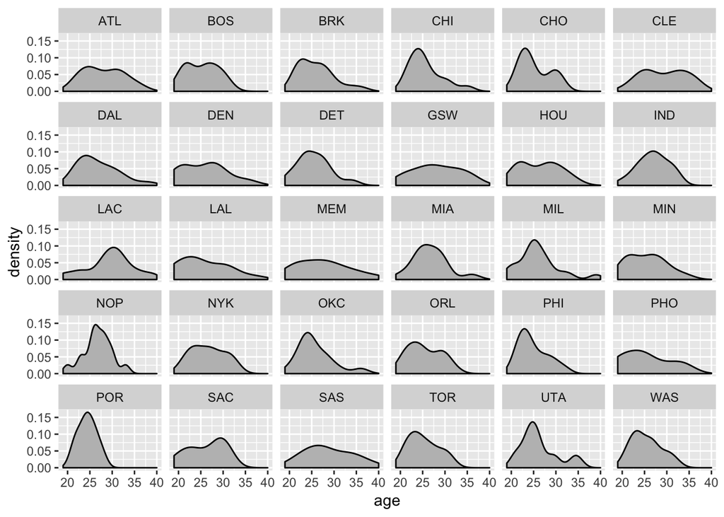

```r
ggplot(dat, aes(x = age)) +geom_density(fill ='gray') +facet_wrap(~ team)
```

- **Make scatterplots of `height` and `weight` faceting by `position`**

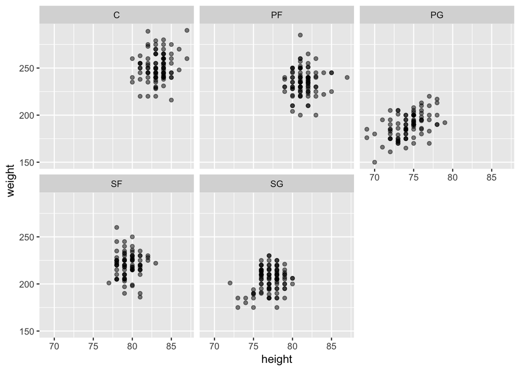

```r
ggplot(dat, aes(x = height, y = weight)) +geom_point(alpha = 0.5) +facet_wrap(~ position)
```

- **Make scatterplots of `height` and `weight`, with a 2-dimensional density, geom_density2d(), faceting by `position`**

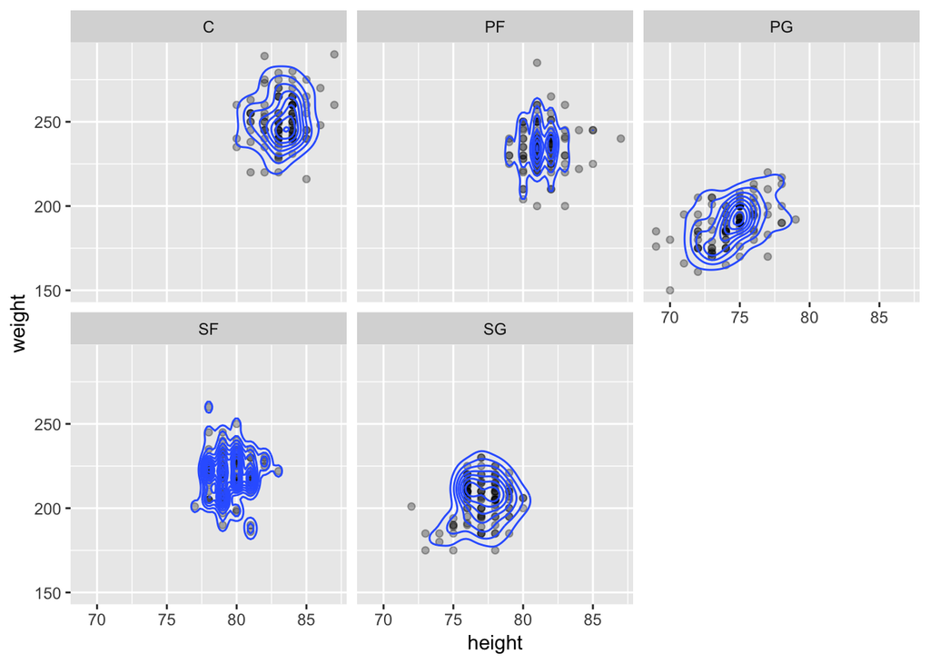

```r
ggplot(dat, aes(x = height, y = weight)) +geom_point(alpha = 0.3) +geom_density2d() +facet_wrap(~ position)
```

- **Make a scatterplot of `experience` and `salary` for the Warriors, but this time add a layer with `theme_bw()` to get a simpler background**

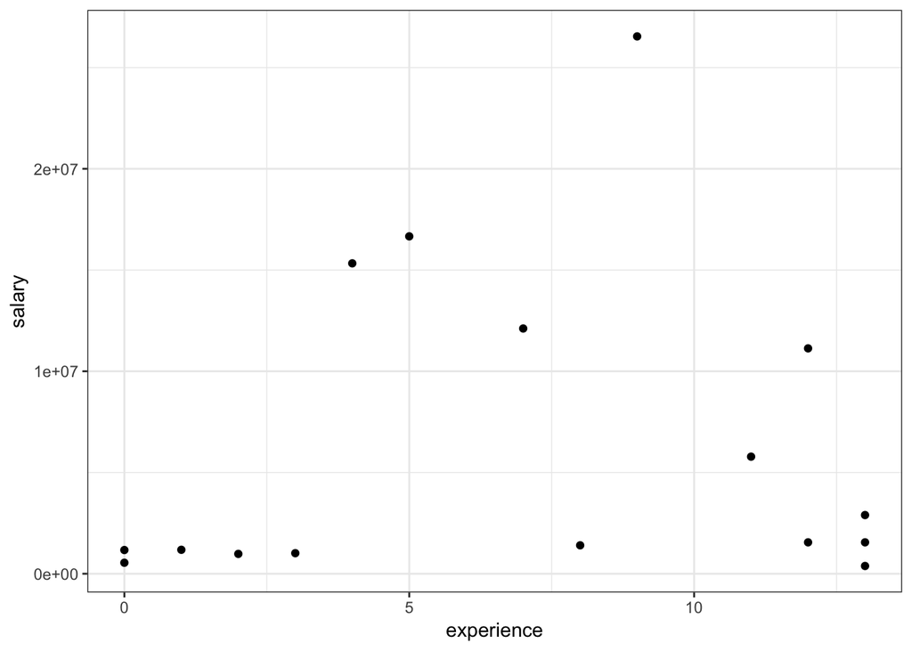

```r
ggplot(filter(dat, team == 'GSW'),aes(x = experience, y = salary)) + geom_point() +theme_bw()
```

- **Repeat any of the previous plots but now adding a leyer with another theme e.g. `theme_minimal()`, `theme_dark()`, `theme_classic()`**

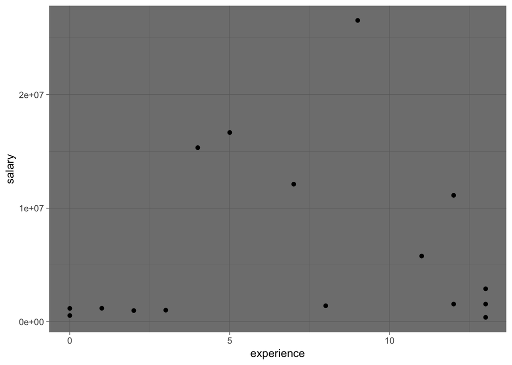

```r
ggplot(filter(dat, team == 'GSW'),aes(x = experience, y = salary)) + geom_point() +theme_dark()
```